# Assignmet 4

| Author: “Linda Dumalo” |
| --- |
| Date: “October 8, 2019” |

## Exercise 1: Univariate Data Reshaping

#### Option 1

Make a tibble with one row per year, and columns for life expectancy for two or more countries.

```r
# target table to have years on the left and "widen" country column
OptI <- gapminder %>%
  filter(country ==  "Canada" | country == "Mexico") %>%
  select(country, year, lifeExp) %>%
  pivot_wider(id_cols = year,
              names_from = country,
              values_from = lifeExp)
OptI %>%
  DT::datatable()
```

|  | year | Canada | Mexico |
| --- | --- | --- | --- |
| 1 | 1952 | 68.75 | 50.789 |
| 2 | 1957 | 69.96 | 55.19 |
| 3 | 1962 | 71.3 | 58.299 |
| 4 | 1967 | 72.13 | 60.11 |
| 5 | 1972 | 72.88 | 62.361 |
| 6 | 1977 | 74.21 | 65.032 |
| 7 | 1982 | 75.76 | 67.405 |
| 8 | 1987 | 76.86 | 69.498 |
| 9 | 1992 | 77.95 | 71.455 |
| 10 | 1997 | 78.61 | 73.67 |

[output cut: 2 more lines]

Relengthen the data.

```r
OptI %>%
  pivot_longer(cols = c("Canada", "Mexico"),
               names_to = "Country",
               values_to = "Life_Exp") %>%
# Order wrong so rearrange
arrange(Country, year, Life_Exp) %>%
DT::datatable()
```

|  | year | Country | Life_Exp |
| --- | --- | --- | --- |
| 1 | 1952 | Canada | 68.75 |
| 2 | 1957 | Canada | 69.96 |
| 3 | 1962 | Canada | 71.3 |
| 4 | 1967 | Canada | 72.13 |
| 5 | 1972 | Canada | 72.88 |
| 6 | 1977 | Canada | 74.21 |
| 7 | 1982 | Canada | 75.76 |
| 8 | 1987 | Canada | 76.86 |
| 9 | 1992 | Canada | 77.95 |
| 10 | 1997 | Canada | 78.61 |

[output cut: 14 more lines]

The Exercise asked to plot the widened data by plotting the 2 countries against each other. Interpreted this as plot one Country on x and 1 country on y. Where each point represents a year and the values for each country are a life epectancy.

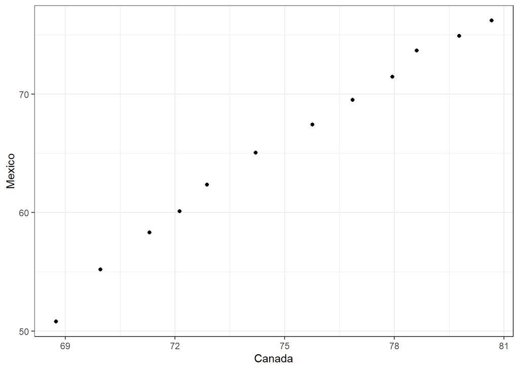

```r
OptI %>%
  ggplot(aes(Canada, Mexico)) +
  geom_point() +
  theme_bw()
```

To compare though how the life expectancies differ between the countries per year it is easier to use the data in the orignal format.

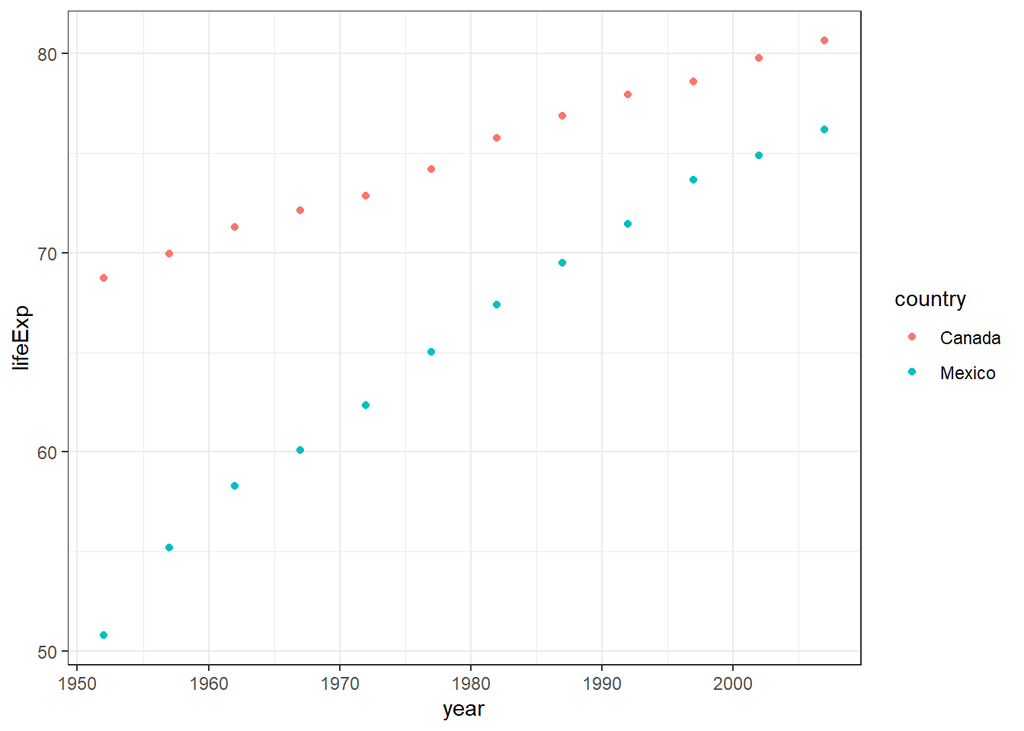

```r
gapminder %>%
  filter(country ==  "Canada" | country == "Mexico") %>%
  select(country, year, lifeExp) %>%
  ggplot(aes(year, lifeExp, fill = country, colour = country)) +
  geom_point() +
  theme_bw()
```

## **Exercise 2** - Multivariate Data

#### Option 1

Make a tibble with one row per year, and columns for life expectancy and GDP per capita (or two other numeric variables) for Canada and Mexico.

```r
# The observation is the combination of country, lifeExp and gdpPercap
OptIM <- gapminder %>%
  filter(country ==  "Canada" | country == "Mexico") %>%
  select(year, country, lifeExp, gdpPercap) %>%
  pivot_wider(id_cols = year,
            names_from = country,
            names_sep = "_",
            values_from = c(lifeExp, gdpPercap))
OptIM %>%
  DT::datatable()
```

|  | year | lifeExp_Canada | lifeExp_Mexico | gdpPercap_Canada | gdpPercap_Mexico |
| --- | --- | --- | --- | --- | --- |
| 1 | 1952 | 68.75 | 50.789 | 11367.16112 | 3478.125529 |
| 2 | 1957 | 69.96 | 55.19 | 12489.95006 | 4131.546641 |
| 3 | 1962 | 71.3 | 58.299 | 13462.48555 | 4581.609385 |
| 4 | 1967 | 72.13 | 60.11 | 16076.58803 | 5754.733883 |
| 5 | 1972 | 72.88 | 62.361 | 18970.57086 | 6809.40669 |
| 6 | 1977 | 74.21 | 65.032 | 22090.88306 | 7674.929108 |
| 7 | 1982 | 75.76 | 67.405 | 22898.79214 | 9611.147541 |
| 8 | 1987 | 76.86 | 69.498 | 26626.51503 | 8688.156003 |
| 9 | 1992 | 77.95 | 71.455 | 26342.88426 | 9472.384295 |
| 10 | 1997 | 78.61 | 73.67 | 28954.92589 | 9767.29753 |

[output cut: 2 more lines]

Relengthen the data

```r
OptIM %>%
  pivot_longer(cols = c(-year), # is this the correct line to start? I think so...
               names_to = c(".value", "country"),
               names_sep = "_") %>%
  arrange(country, year) %>%
DT::datatable()
```

|  | year | country | lifeExp | gdpPercap |
| --- | --- | --- | --- | --- |
| 1 | 1952 | Canada | 68.75 | 11367.16112 |
| 2 | 1957 | Canada | 69.96 | 12489.95006 |
| 3 | 1962 | Canada | 71.3 | 13462.48555 |
| 4 | 1967 | Canada | 72.13 | 16076.58803 |
| 5 | 1972 | Canada | 72.88 | 18970.57086 |
| 6 | 1977 | Canada | 74.21 | 22090.88306 |
| 7 | 1982 | Canada | 75.76 | 22898.79214 |
| 8 | 1987 | Canada | 76.86 | 26626.51503 |
| 9 | 1992 | Canada | 77.95 | 26342.88426 |
| 10 | 1997 | Canada | 78.61 | 28954.92589 |

[output cut: 14 more lines]

## **Exercise 3** - Table Joins

```r
guest <- read_csv("https://raw.githubusercontent.com/STAT545-UBC/Classroom/master/data/wedding/attend.csv")
email <- read_csv("https://raw.githubusercontent.com/STAT545-UBC/Classroom/master/data/wedding/emails.csv")
```

#### **3.1**

Add an email column from the email tibble to the guest tibble.

```r
head(guest)
```

```
## # A tibble: 6 x 7
##   party name  meal_wedding meal_brunch attendance_wedd~ attendance_brun~
##   <dbl> <chr> <chr>        <chr>       <chr>            <chr>
## 1     1 Somm~ PENDING      PENDING     PENDING          PENDING
## 2     1 Phil~ vegetarian   Menu C      CONFIRMED        CONFIRMED
## 3     1 Blan~ chicken      Menu A      CONFIRMED        CONFIRMED
## 4     1 Emaa~ PENDING      PENDING     PENDING          PENDING
## 5     2 Blai~ chicken      Menu C      CONFIRMED        CONFIRMED
## 6     2 Nige~ <NA>         <NA>        CANCELLED        CANCELLED
## # ... with 1 more variable: attendance_golf <chr>
```

```r
head(email)
```

```
## # A tibble: 6 x 2
##   guest                                                   email
##   <chr>                                                   <chr>
## 1 Sommer Medrano, Phillip Medrano, Blanka Medrano, Emaan~ sommm@gmail.com
## 2 Blair Park, Nigel Webb                                  bpark@gmail.com
## 3 Sinead English                                          singlish@hotmail~
## 4 Ayra Marks                                              marksa42@gmail.c~
## 5 Jolene Welsh, Hayley Booker                             jw1987@hotmail.c~
## 6 Amayah Sanford, Erika Foley                             erikaaaaaa@gmail~
```

In order to perform the join functions, the email tibble format needs to be changed to match the guest tibble.

The changes that need to be made to the email tibble are:

1. Have one observation ie name per row
2. Change column name guest to name.

```r
email2 <- email %>%
  separate_rows(guest, sep = ", ") %>%
  rename("name" = "guest")
email2 %>%
  DT::datatable()
```

|  | name | email |
| --- | --- | --- |
| 1 | Sommer Medrano | sommm@gmail.com |
| 2 | Phillip Medrano | sommm@gmail.com |
| 3 | Blanka Medrano | sommm@gmail.com |
| 4 | Emaan Medrano | sommm@gmail.com |
| 5 | Blair Park | bpark@gmail.com |
| 6 | Nigel Webb | bpark@gmail.com |
| 7 | Sinead English | singlish@hotmail.ca |
| 8 | Ayra Marks | marksa42@gmail.com |
| 9 | Jolene Welsh | jw1987@hotmail.com |
| 10 | Hayley Booker | jw1987@hotmail.com |

[output cut: 18 more lines]

```r
guest %>%
  left_join(email2, by = "name") %>%
# left join was used to keep all the observations
  DT::datatable()
```

|  | party | name | meal_wedding | meal_brunch | attendance_wedding | attendance_brunch | attendance_golf | email |
| --- | --- | --- | --- | --- | --- | --- | --- | --- |
| 1 | 1 | Sommer Medrano | PENDING | PENDING | PENDING | PENDING | PENDING | sommm@gmail.com |
| 2 | 1 | Phillip Medrano | vegetarian | Menu C | CONFIRMED | CONFIRMED | CONFIRMED | sommm@gmail.com |
| 3 | 1 | Blanka Medrano | chicken | Menu A | CONFIRMED | CONFIRMED | CONFIRMED | sommm@gmail.com |
| 4 | 1 | Emaan Medrano | PENDING | PENDING | PENDING | PENDING | PENDING | sommm@gmail.com |
| 5 | 2 | Blair Park | chicken | Menu C | CONFIRMED | CONFIRMED | CONFIRMED | bpark@gmail.com |
| 6 | 2 | Nigel Webb |  |  | CANCELLED | CANCELLED | CANCELLED | bpark@gmail.com |
| 7 | 3 | Sinead English | PENDING | PENDING | PENDING | PENDING | PENDING | singlish@hotmail.ca |
| 8 | 4 | Ayra Marks | vegetarian | Menu B | PENDING | PENDING | PENDING | marksa42@gmail.com |
| 9 | 5 | Atlanta Connolly | PENDING | PENDING | PENDING | PENDING | PENDING |  |
| 10 | 5 | Denzel Connolly | fish | Menu B | CONFIRMED | CONFIRMED | CONFIRMED |  |

[output cut: 20 more lines]

#### **3.2**

Who are there emails for but are not on the guest list? Not being on the guest list is to be intrepted as not having a meal or being in attendance to any event which also equates to not being in a party ie party *NA*

```r
guest %>%
  full_join(email2, by = "name") %>%
  filter(is.na(party)) %>%
  select(party, name, attendance_wedding, email)
```

```
## # A tibble: 3 x 4
##   party name            attendance_wedding email
##   <dbl> <chr>           <chr>              <chr>
## 1    NA Turner Jones    <NA>               tjjones12@hotmail.ca
## 2    NA Albert Marshall <NA>               themarshallfamily1234@gmail.com
## 3    NA Vivian Marshall <NA>               themarshallfamily1234@gmail.com
```

Those who are not on the guest list but there was an email for were Turner Jones and Albert and Vivian Marshall.

#### **3.3**

Make a guestlist that includes everyone we have emails for (in addition to those on the original guestlist).

```r
guest %>%
  right_join(email2, by = "name") %>%
  select(party, name, email)
```

```
## # A tibble: 28 x 3
##    party name            email
##    <dbl> <chr>           <chr>
##  1     1 Sommer Medrano  sommm@gmail.com
##  2     1 Phillip Medrano sommm@gmail.com
##  3     1 Blanka Medrano  sommm@gmail.com
##  4     1 Emaan Medrano   sommm@gmail.com
##  5     2 Blair Park      bpark@gmail.com
##  6     2 Nigel Webb      bpark@gmail.com
##  7     3 Sinead English  singlish@hotmail.ca
##  8     4 Ayra Marks      marksa42@gmail.com
##  9     6 Jolene Welsh    jw1987@hotmail.com
## 10     6 Hayley Booker   jw1987@hotmail.com
## # ... with 18 more rows
```